# Lecture #8

R - 언어의 색깔 설정

Junho Ahn

2022-09-08

## 그래픽 함수의 col 옵션

### col에 색깔을 설정하는 방법

- col이라는 매개변수 사용
  - 0 ~ 8까지의 숫자로 기본색깔만 설정
  - 색의 이름으로 설정
  - rgb 함수로 빛의 삼원색인 빨강, 녹색, 파랑(Red, Green, Blue; RGB)로 설정
  - hsv 함수로 색상, 채도, 명도(Hue, Saturation, Value(Brightness) ; HSV, HSB)로 설정
  - 내장함수인 rainbow, topo.cocolors, heat.colors를 사용하는 방법
  - 무채색인 경우 grey(또는 gray) 함수로 설정

### 숫자로 설정

숫자로 색깔을 설정할 때 8보다 큰 수로 설정하면 1번 색깔(검정)부터 8번까지를 반복

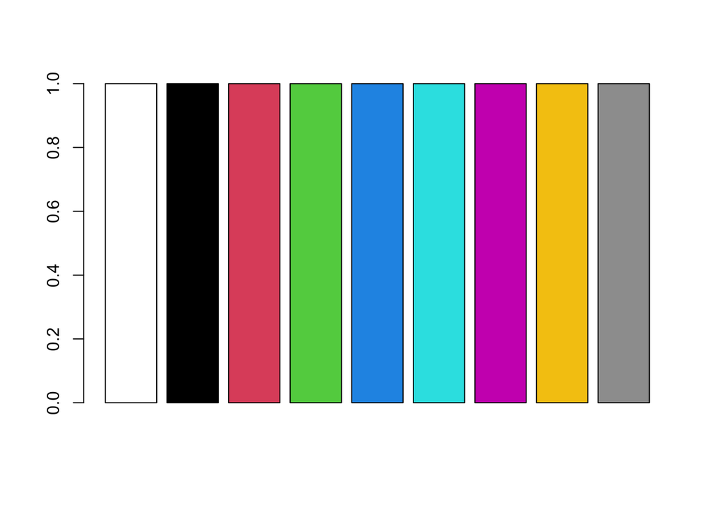

```r
barplot(rep(1,9), col=0:8)
```

색깔번호를 9이상 설정할 때 나오는 색깔

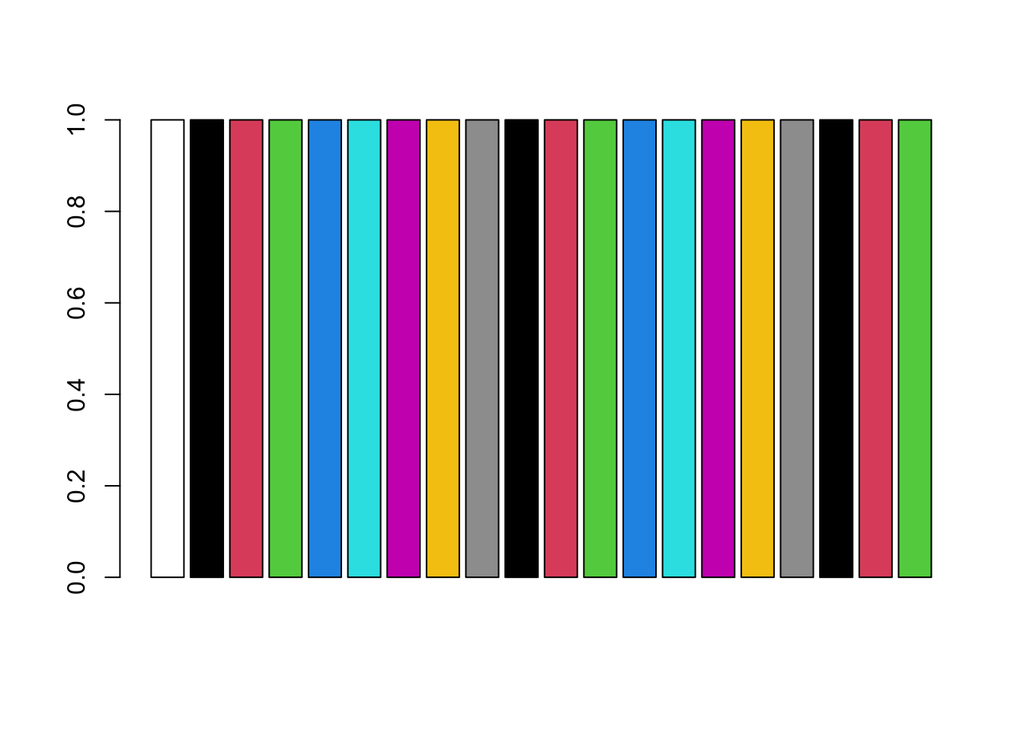

```r
barplot(rep(1,20), col=0:20)
```

### 색의 이름으로 설정

알려진 색의 경우 색이름을 사용  
- red, green, blue, white, cyan, magenta, yellow, black, orange 등  
- R에서 색 이름을 설정할 때는 반드시 따옴표를 사용해야 함

색을 사용할 개수와 설정한 색의 개수가 일치하지 않을 경우에는 색을 (반복)돌려가며 사용  
(예. 색이 필요한 곳이 두 곳인데 설정한 색이 하나이면 모두 같은 색으로 칠해짐)

```r
BMI <- read.csv("./Lecture01_BMI.csv")
```

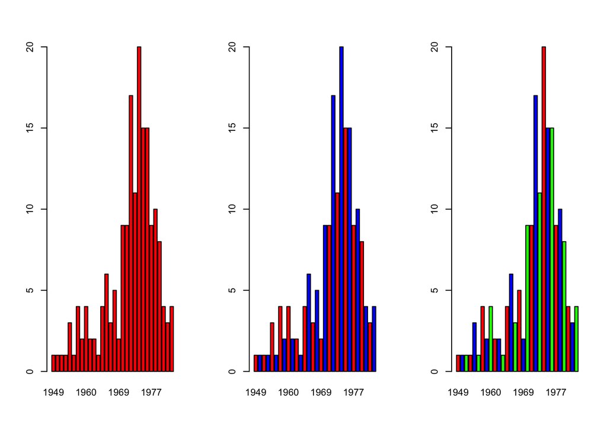

```r
par(mfrow=c(1,3))
barplot(table(BMI[,4]), col="red")
barplot(table(BMI[,4]), col=c("red", "blue"))
barplot(table(BMI[,4]), col=c("red", "blue", "green"))
```

R에서 사용할 수 있는 색의 이름은 아래와 같이 확인할 수 있음.

```r
# Generate a plot of color names which R knows about.
#++++++++++++++++++++++++++++++++++++++++++++
# cl : a vector of colors to plots
# bg: background of the plot
# rot: text rotation angle
#usage=showCols(bg="gray33")
showCols <- function(cl=colors(), bg = "grey",
                     cex = 0.75, rot = 30) {
    m <- ceiling(sqrt(n <-length(cl)))
    length(cl) <- m*m; cm <- matrix(cl, m)
    require("grid")
    grid.newpage(); vp <- viewport(w = .92, h = .92)
    grid.rect(gp=gpar(fill=bg))
    grid.text(cm, x = col(cm)/m, y = rev(row(cm))/m, rot = rot,
              vp=vp, gp=gpar(cex = cex, col = cm))
  }
```

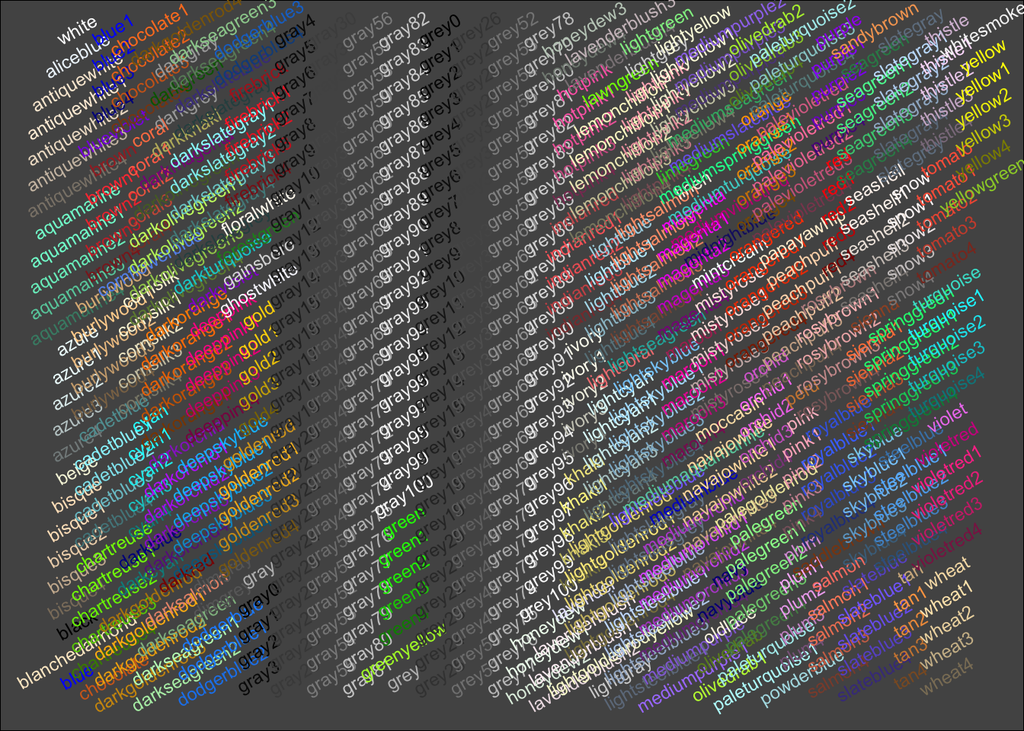

```r
showCols(cl= colors(), bg="gray33", rot=30, cex=0.75)
```

## rgb 함수

red, green, blue, alpha 순서로 0~1사이의 숫자로 빨강, 녹색, 파랑의 색의 농도를 설정하며, 0이 최소, 1이 최대임.

- rgb(0,0,0)은 세가지 색이 모두 없으므로 검정(black)
- rgb(1,1,1)은 세가지 색이 모두 최대로 설정되므로 흰색(white)
- rgb(1,0,0)은 빨강색만 최대이므로 빨강(red)
- alpha는 투명한 정도를 설정하며 1=불투명, 0=투명으로 생략가능함 (기본값 = 1)

### rgb 함수로 색을 설정하는 법

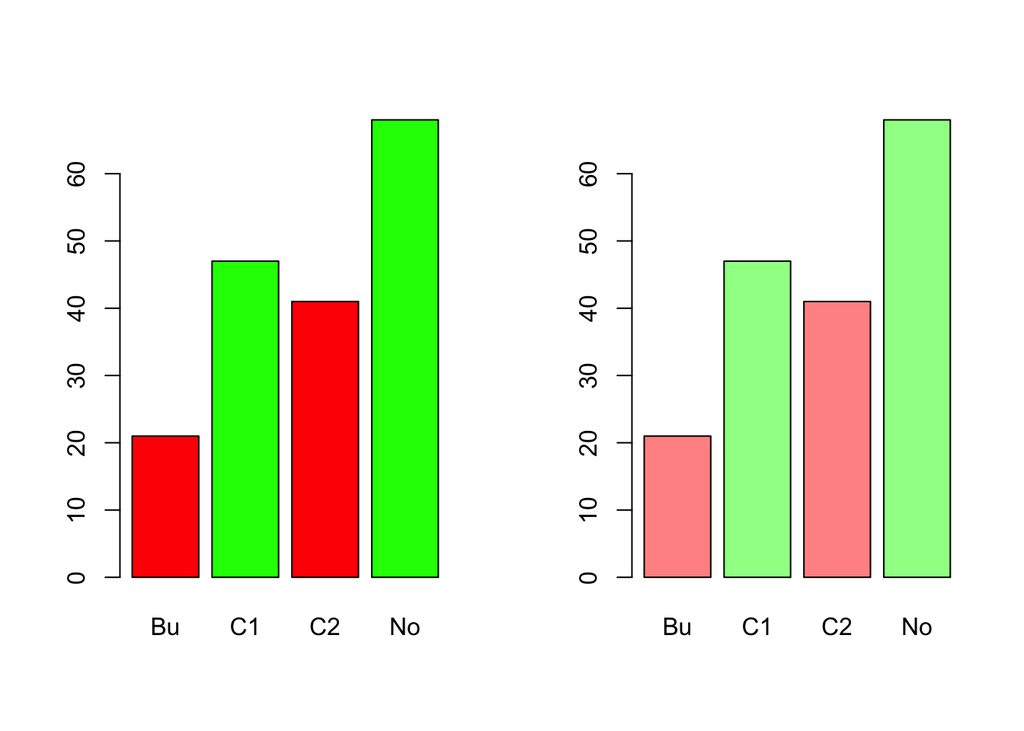

```r
par(mfrow=c(1,2))
barplot(table(BMI[,5]), col=c(rgb(1,0,0), rgb(0,1,0)))
barplot(table(BMI[,5]), col=c(rgb(1,0,0, 0.5), rgb(0,1,0, 0.5)))
```

### 투명도 alpha

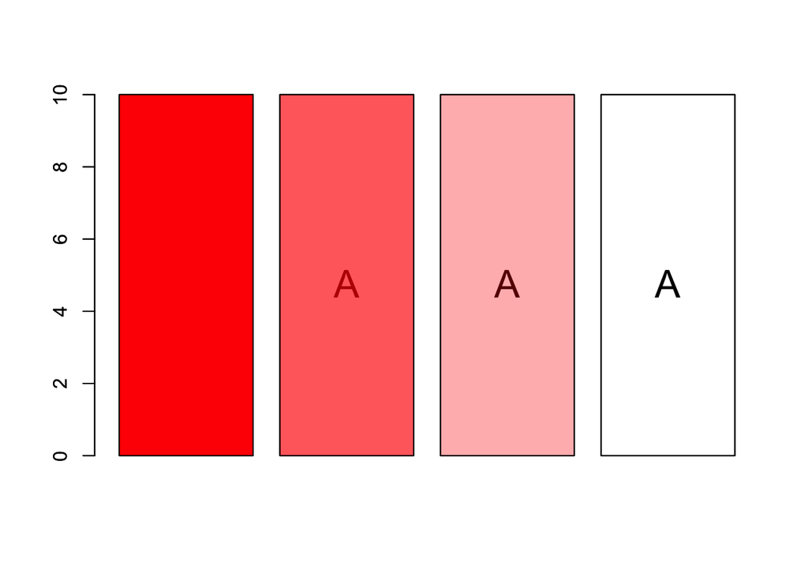

```r
mycol <- c(rgb(1,0,0,1), rgb(1,0,0,0.67), rgb(1,0,0,0.33), rgb(1,0,0,0))
x <- rep(10,4)
bp <- barplot(x, col=rgb(1,1,1))
y <- rep(4.77,4)
txt <- rep("A",4)
text(bp, y, txt, cex=2)

barplot(x, col=mycol, add=TRUE)
```

- mycol: 빨강에서 투명도를 네 단계로 설정하고 높이 10인 막대그래프를 그림
- y: 높이 bp는 각 기둥의 중앙 x좌표로 설정하여 기둥의 중앙에 문자열 A를 그림
- `text()`함수: 기존 그래프에 문자열을 임의의 위치에 그려 넣은 함수
- `barplot()`함수: 같은 자료 x에 대한 막대그래프를 그리지만 색깔은 앞의 네 가지 서로 다른 투명도의 색으로 하고, add 옵션에 의해 기존 그래프에 추가됨.

## hsv 함수

HSV 색상은 때로 HSB(=brightness)로 부르기도 하나 R에서는 hsv로 사용함

- hue, saturation, value, alpha 값을 순서대로 0~1 사이의 값으로 설정
- alpha 값은 투명한 정도를 설정 (기본값 = 1)

### 색상, 채도, 명도의 값을 설정하는 방법

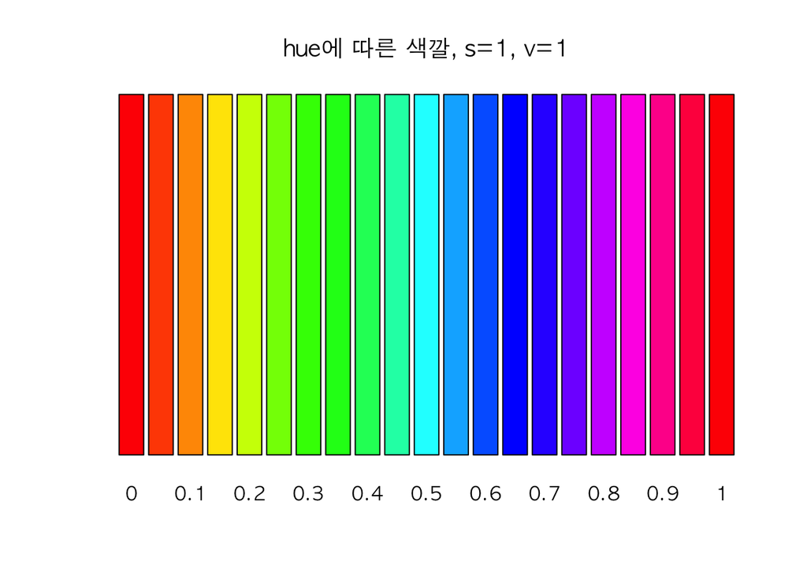

```r
mycol <- NULL

for(i in 0:20){
  mycol <- c(mycol, hsv(i/20,1,1))
}

par(family = "AppleGothic")
barplot(rep(10,21), col=mycol, names.arg = as.character(seq(0,20)/20),
        yaxt="n", main="hue에 따른 색깔, s=1, v=1")
```

채도를 0.5로 낮춘 결과

[figure not shown]

```r
mycol <- NULL

for(i in 0:20){
  mycol <- c(mycol, hsv(i/20,0.5,1))
}

par(family = "AppleGothic")
barplot(rep(10,21), col=mycol, names.arg = as.character(seq(0,20)/20),
        yaxt="n", main="hue에 따른 색깔, s=1, v=1")
```

명도를 0.5로 낮춘 결과

[figure not shown]

```r
mycol <- NULL

for(i in 0:20){
  mycol <- c(mycol, hsv(i/20,1,0.5))
}

par(family = "AppleGothic")
barplot(rep(10,21), col=mycol, names.arg = as.character(seq(0,20)/20),
        yaxt="n", main="hue에 따른 색깔, s=1, v=1")
```

## rainbow, heat.colors, topo.colors 함수

### 색상, 채도, 명도의 값을 설정하는 방법

- `rainbow()`: 무지개 색
- `heat.colors()`: 열 표현
- `topo.colors()`: 지도의 등고선

### rainbow, heat.colors, topo.colors 함수

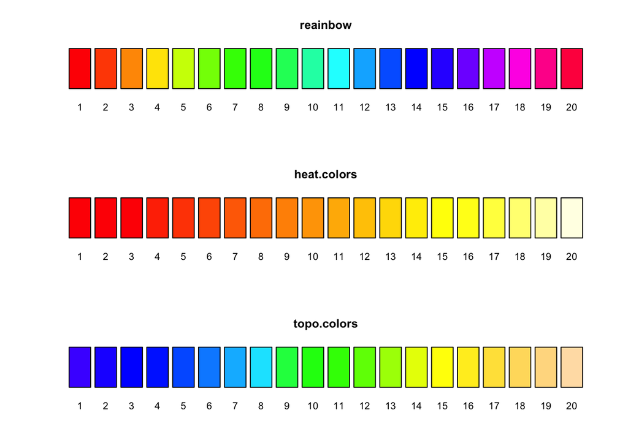

```r
par(mfrow=c(3,1))
barplot(rep(10,20), col=rainbow(20), names.arg = as.character(seq(1,20)), yaxt="n", main = "reainbow")
barplot(rep(10,20), col=heat.colors(20), names.arg = as.character(seq(1,20)), yaxt="n", main = "heat.colors")
barplot(rep(10,20), col=topo.colors(20), names.arg = as.character(seq(1,20)), yaxt="n", main = "topo.colors")
```